# MATH3421 Workshop 1 Solutions

AY24/25 Week 5

## Preliminaries

These solutions were produced using Rmarkdown. *After the workshop* (or if time permits), have a look at the corresponding .Rmd file and the following instructions.

If using Rmarkdown for the first time (e.g. on your own laptop or every time you use appsanywhere), you may need to execute the following code.

```r
install.packages("rmarkdown")
install.packages("tinytex")
library(rmarkdown)
tinytex::install_tinytex()
```

The latter is used for producing pdf files, and creates a local LaTeX installation. If you’re just wanting to knit to html, you don’t need the tinytex installation. Finally, if you’re using the codespaces option of running RStudio, you don’t need the above code chunk at all.

## Question 1 (Random walk Metropolis)

Consider a $\text{N}(0,1)$ target, a random walk proposal with $\text{U}(-a,a)$ innovations and the following function:

```r
norm<-function(N,a)
{
 vec <- rep(0,N)  # store samples here
 theta <- 0 # initial value
 vec[1] <- theta # store initial value
 for (i in 2:N)
 {
  innov <- runif(1,-a,a) # generate innovation
  can <- theta + innov   # proposal
  laprob <- dnorm(can,log=TRUE)-dnorm(theta,log=TRUE) # log of acc. prob.
  u <- runif(1)
  if (log(u) < laprob){
   theta <- can # accept
  }
   vec[i] <- theta #store most recent theta
  }
 return(vec) #return vector of samples
}
```

Note that the proposal density is $q(\theta^*|\theta)=1/2a$, for $\theta-a<\theta^*<\theta+a$ and 0 otherwise.

1. Vary the tuning parameter $a$ that governs the proposal distribution.

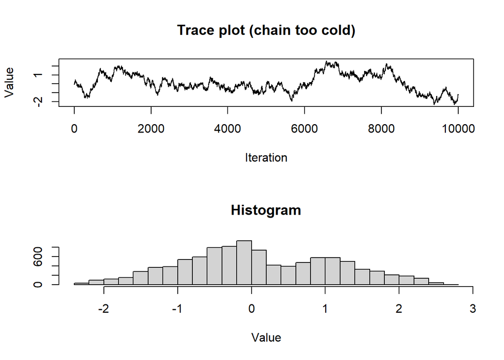

```r
normvec <- norm(10000,0.1) #too cold
par(mfrow=c(2,1))
plot(ts(normvec),ylab="Value",xlab="Iteration",main="Trace plot (chain too cold)")
hist(normvec,30,ylab="",xlab="Value",main="Histogram")
```

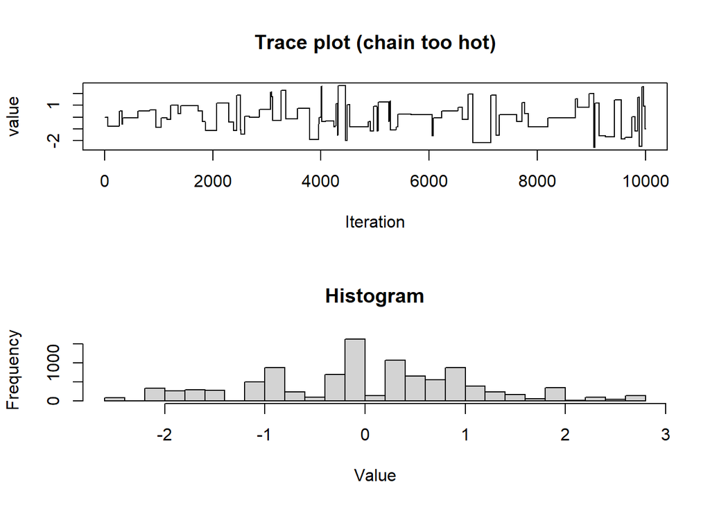

```r
normvec <- norm(10000,200) #too hot
par(mfrow=c(2,1))
plot(ts(normvec),ylab="value",xlab="Iteration",main="Trace plot (chain too hot)")
hist(normvec,30,xlab="Value",main="Histogram")
```

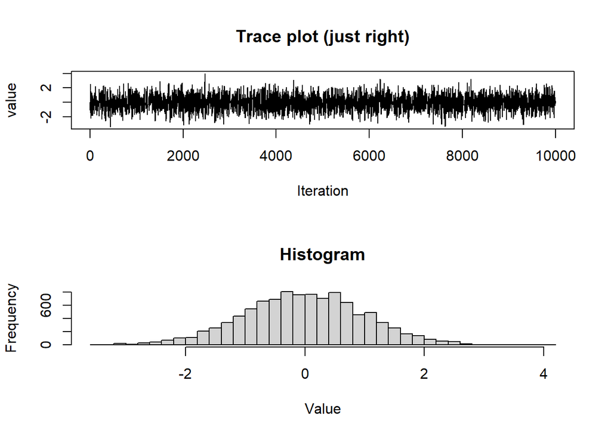

```r
normvec <- norm(10000,4) #just right
par(mfrow=c(2,1))
plot(ts(normvec),ylab="value",xlab="Iteration",main="Trace plot (just right)")
hist(normvec,30,xlab="Value",main="Histogram")
```

2. Modify to print empirical overall acceptance rate.

```r
norm<-function(N,a)
{
 vec <- rep(0,N)
 theta <- 0
 count <- 0
 vec[1] <- theta
 for (i in 2:N)
 {
  innov <- runif(1,-a,a)
  can <- theta + innov
  laprob <- dnorm(can,log=TRUE)-dnorm(theta,log=TRUE)
  u <- runif(1)
  if (log(u) < laprob){
   theta <- can
   count <- count+1
  }
   vec[i] <- theta
  }
 print(count/(N-1)) #empirical overall acceptance rate
 return(vec)
}

normvec <- norm(100000,4) #acceptance rate should be around 0.4 with a=4
```

```
## [1] 0.3911439
```

3. Produce a histogram of 100k samples and target $N(0,1)$ density overlaid.

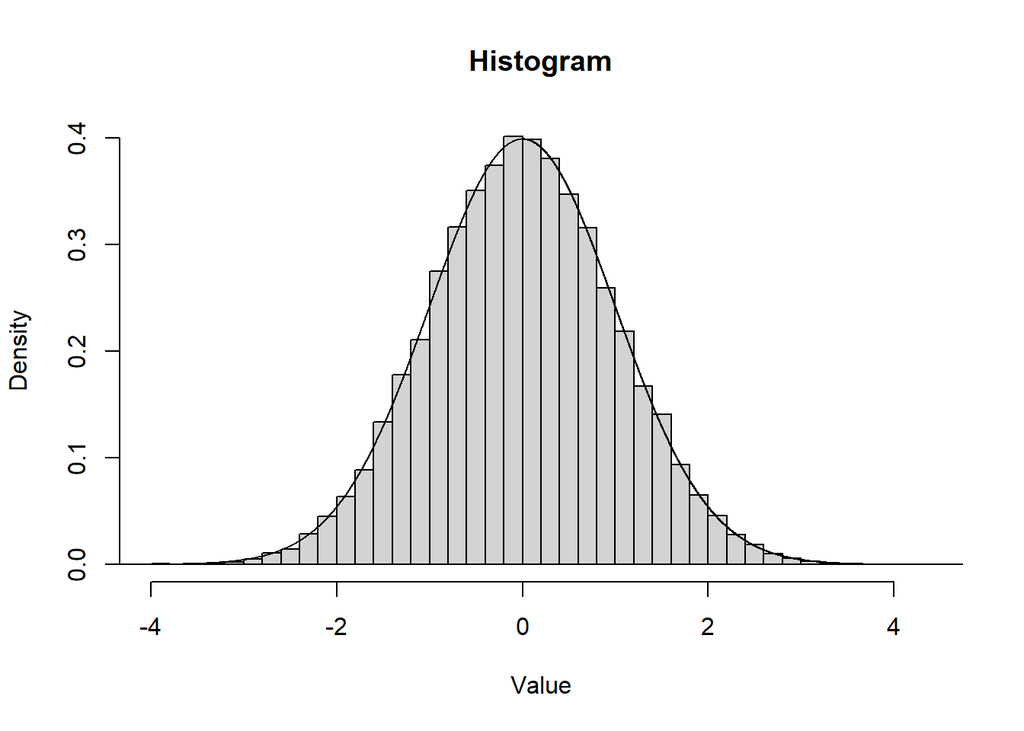

```r
hist(normvec,30,freq=FALSE,xlab="Value",main="Histogram") #"freq=FALSE" so that area is 1
lines(seq(-6,6,0.001),dnorm(seq(-6,6,0.001)),type="l")
```

4. Add the initial value of the chain as a function argument.

```r
norm<-function(N,a,theta)
{
 vec <- rep(0,N)
 count <- 0
 vec[1] <- theta
 for (i in 2:N)
 {
  innov <- runif(1,-a,a)
  can <- theta + innov
  laprob <- dnorm(can,log=TRUE)-dnorm(theta,log=TRUE)
  u <- runif(1)
  if (log(u) < laprob){
   theta <- can
   count <- count+1
  }
   vec[i] <- theta
  }
 print(count/(N-1)) #empirical overall acceptance rate
 return(vec)
}

normvec<-norm(1000,4,100) #start at theta=100 (well into the right tail of the target)
```

```
## [1] 0.3933934
```

Produce trace plot and overlay output from different starting values. Let’s do an extra 20 runs with $\theta^{(0)}$ uniformly sampled in the range $[-10,10]$

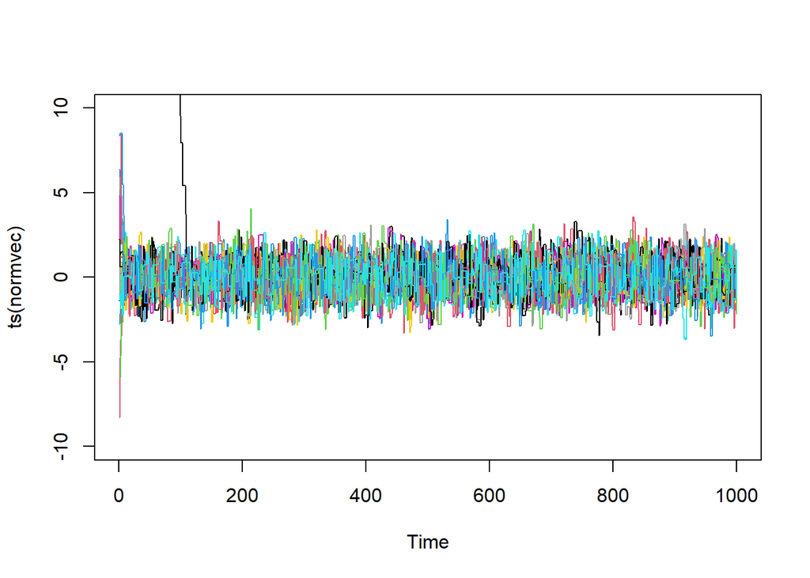

```
## [1] 0.3943944
## [1] 0.3853854
## [1] 0.3903904
## [1] 0.3883884
## [1] 0.3973974
## [1] 0.3863864
## [1] 0.3923924
## [1] 0.4094094
## [1] 0.4154154
## [1] 0.3963964
## [1] 0.4144144
## [1] 0.4114114
## [1] 0.3733734
## [1] 0.4094094
## [1] 0.4284284
## [1] 0.4194194
## [1] 0.3743744
## [1] 0.3853854
## [1] 0.3863864
## [1] 0.3893894
```

```r
plot(ts(normvec),ylim=c(-10,10))
for(i in 1:20)
{
 lines(ts(norm(1000,4,runif(1,-10,10))),col=(i+1))
}
```

**Comment:** for initial values in regions of low target density, the burn-in period can be substantial. Plotting the output from multiple chains with different starting values can give a useful (visual) diagnostic for assessing convergence. This guards against the notion of pseudo-convergence which can arise when only a short run of a single chain is used to assess convergence.

## Question 2 (A simple Metropolis-Hastings independence sampler)

Consider a $\text{Gamma}(a,b)$ target, normal proposal (with mean and variance to match the target). The sampler is coded via the following function.

```r
gammaMH<-function(N,a,b)
{
 mu <- a/b; sig <- sqrt(a/(b*b))
 vec <- rep(0,N)
 theta <- a/b
 vec[1] <- theta
 for (i in 2:N)
 {
  can <- rnorm(1,mu,sig)
  #split acc. prob. for easier display
  laprob1 <- dgamma(can,a,b,log=TRUE)-dgamma(theta,a,b,log=TRUE)
  laprob2 <- dnorm(theta,mu,sig,log=TRUE)-dnorm(can,mu,sig,log=TRUE)
  laprob <- laprob1+laprob2
  u <- runif(1)
  if (log(u) < laprob){
   theta <- can
  }
   vec[i] <- theta
  }
 return(vec)
}
```

1. Try $a=0.1$, $b=0.01$.

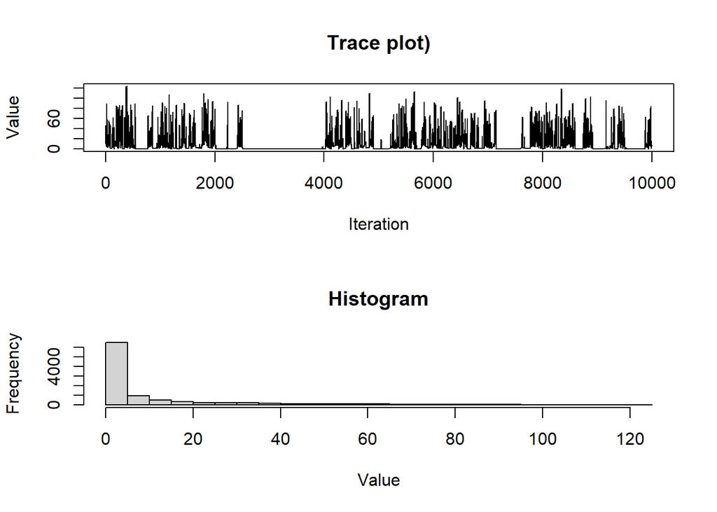

```r
vec <- gammaMH(10000,0.1,0.01)
par(mfrow=c(2,1))
plot(ts(vec),ylab="Value",xlab="Iteration",main="Trace plot)")
hist(vec,30,xlab="Value",main="Histogram")
```

2. Target and proposal overlaid.

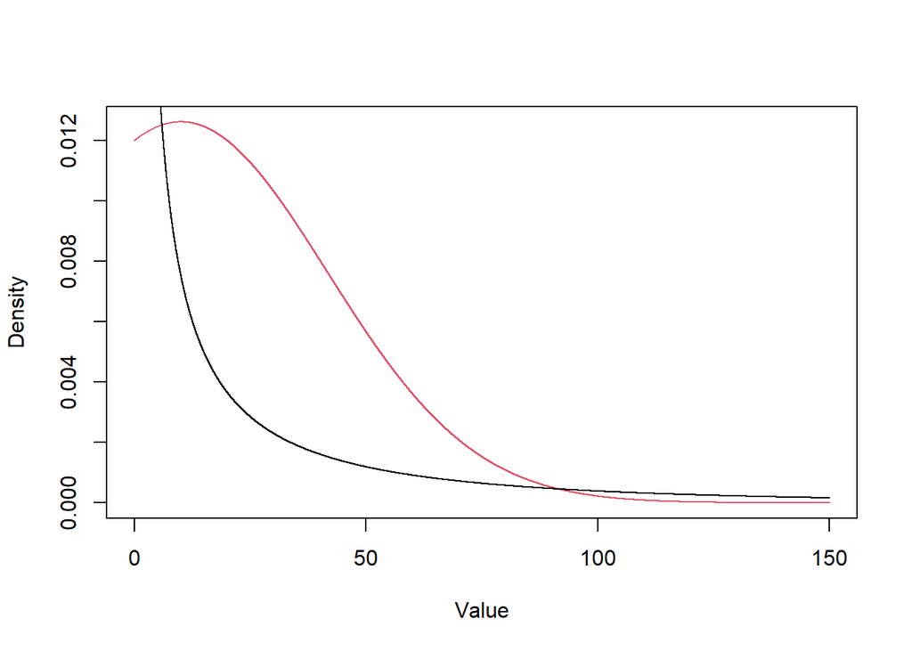

```r
a <- 0.1; b <- 0.01
s <- seq(0,150,0.001)
plot(s,dnorm(s,a/b,sqrt(a/(b*b))),type="l",col=2,ylab="Density",xlab="Value")
lines(s,dgamma(s,a,b),type="l")
```

**Comment:** the proposal density appears to be lighter tailed than the target. The target density exhibits a vertical asymptote as $\theta\to 0$.

3. Modify the sampler to also return the log of the target density and proposal density at the current value of the chain.

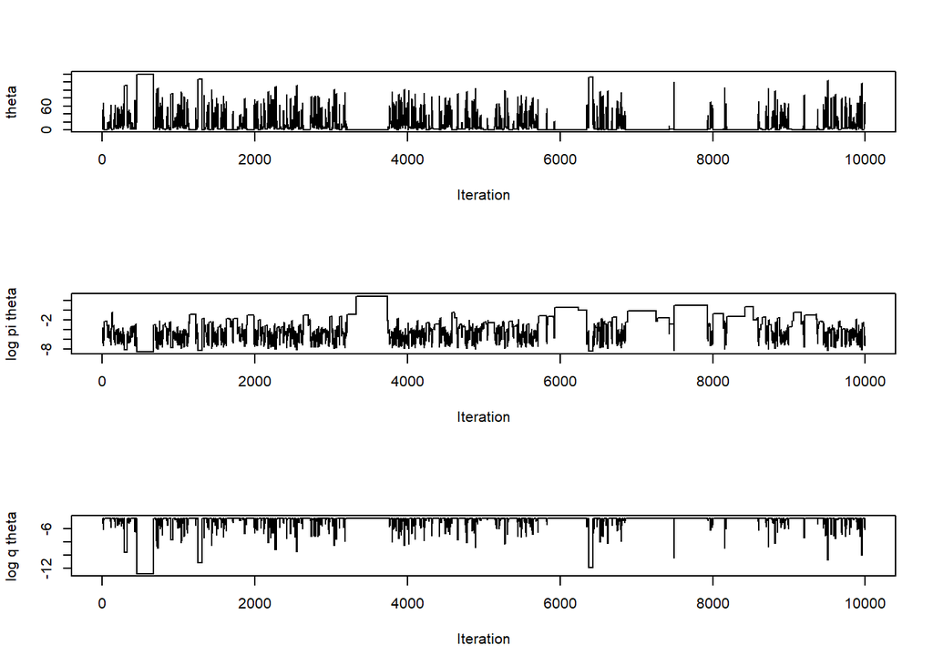

```r
gammaMH<-function(N,a,b)
{
 mu <- a/b; sig <- sqrt(a/(b*b))
 mat <- matrix(0,nrow=N,ncol=3) #add extra columns to store \log\pi and \log q
 theta <- a/b
 mat[1,] <- c(theta,dgamma(theta,a,b,log=TRUE),dnorm(theta,mu,sig,log=TRUE))
 for (i in 2:N)
 {
  can <- rnorm(1,mu,sig)
  laprob1 <- dgamma(can,a,b,log=TRUE)-dgamma(theta,a,b,log=TRUE)
  laprob2 <- dnorm(theta,mu,sig,log=TRUE)-dnorm(can,mu,sig,log=TRUE)
  laprob <- laprob1+laprob2
  u <- runif(1)
  if (log(u) < laprob){
   theta <- can
  }
   mat[i,] <- c(theta,dgamma(theta,a,b,log=TRUE),dnorm(theta,mu,sig,log=TRUE))
  }
 return(mat)
}

mat <- gammaMH(10000,0.1,0.01)
#Trace plots
par(mfrow=c(3,1))
plot(ts(mat[,1]),ylab="theta",xlab="Iteration")
plot(ts(mat[,2]),ylab="log pi theta",xlab="Iteration")
plot(ts(mat[,3]),ylab="log q theta",xlab="Iteration")
```

**Comment 2:** the chain gets stuck at large values of $\theta$ due to the small values of the corresponding $q(\theta)$. That is, these values are likely under the target but not the proposal. (This doesn’t happen so often so you might need a longer run to see this.)

## Question 3 (Crude oil volatility analysis)

Here, we repeat the analysis from problems class 1, but with a prior that precludes a conjugate analysis! Hence the need for Metropolis-Hastings.

We are given the following function:

```r
#Function to evaluate \log\pi(\psi|y) up to an additive constant

lpost<-function(psi)
{
 lprior <- dnorm(psi,log=TRUE)
 llike <- -25*psi-0.5*0.0305/exp(2*psi)
 return(lprior+llike)
}
```

1. The following takes as arguments, the number of iterations `N` and the innovation standard deviation `lambda`, and returns (dependent) samples from the target posterior $\pi(\psi|\boldsymbol{y})$.

```r
rwm<-function(N,lambda)
{
 vec <- rep(0,N)
 psi <- 0
 vec[1] <- psi
 for (i in 2:N)
 {
  innov <- rnorm(1,0,lambda)
  can <- psi + innov
  laprob <- lpost(can)-lpost(psi)
  u <- runif(1)
  if (log(u) < laprob){
   psi <- can
  }
   vec[i] <- psi
  }
 return(vec)
}
```

(b), (c) Run for $N=10k$ iterations with $\lambda=0.1$:

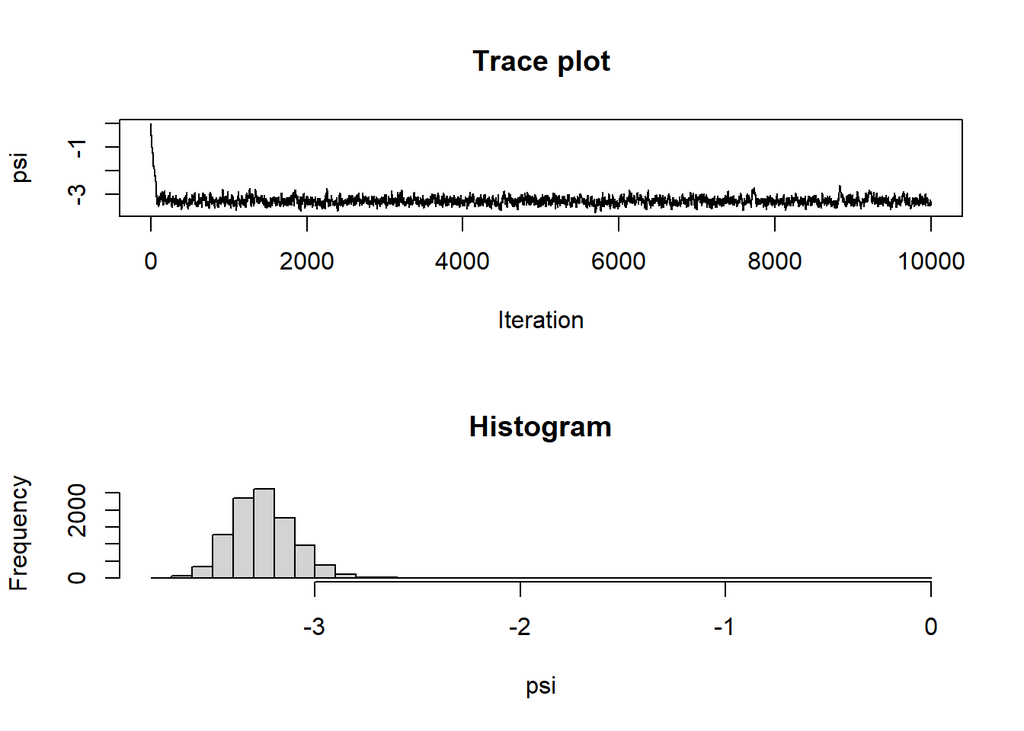

```r
out <- rwm(10000,0.1)
par(mfrow=c(2,1))
plot(ts(out),ylab="psi",xlab="Iteration",main="Trace plot")
hist(out,30,xlab="psi",main="Histogram")
```

Remove burn-in and replot:

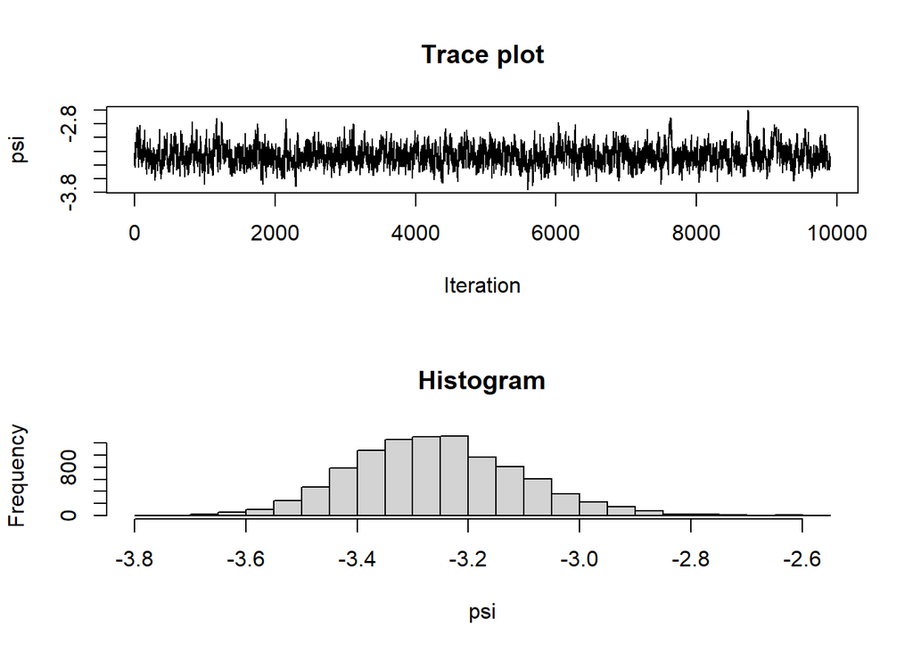

```r
par(mfrow=c(2,1))
plot(ts(out[101:10000]),ylab="psi",xlab="Iteration",main="Trace plot")
hist(out[101:10000],30,xlab="psi",main="Histogram")
```

```r
#Remove burn-in and transform output to set sigma samples

sigout <- exp(out[101:10000])

#Posterior summaries
mean(sigout)
```

```
## [1] 0.03895333
```

```r
var(sigout)
```

```
## [1] 3.707748e-05
```

```r
quantile(sigout,c(0.025,0.975))
```

```
##       2.5%      97.5%
## 0.02927902 0.05308304
```

4. Generate (conditionally independent) samples from the posterior predictive for $Y_{26}$ and produce a histogram:

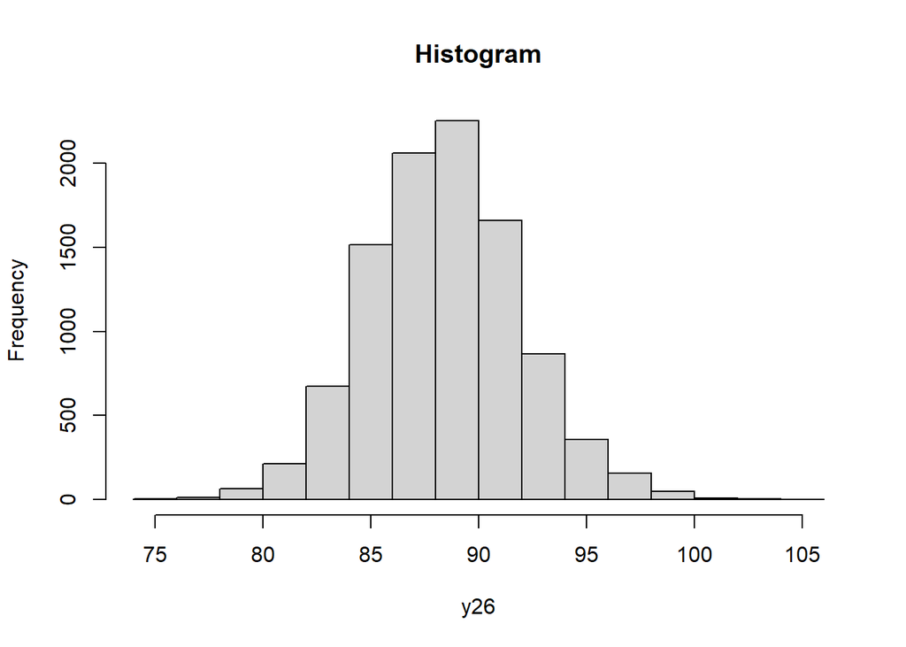

```r
Ns <- length(sigout)
y26 <- rep(0,Ns)

for(i in 1:Ns)
{
 y26[i] <- 88.35*exp(rnorm(1,0,sigout[i]))
}

hist(y26,xlab="y26",main="Histogram")
```

The actual value of $y_{26}=90.66$ is consistent with sampled values from the predictive. In fact, an equi-tailed 95% credible interval is

```r
quantile(y26,c(0.025,0.975))
```

```
##     2.5%    97.5%
## 81.77607 95.71680
```

It is also possible to generate the $y_{26}$ samples without using a `for` loop, by asking `rnorm` for a vector of draws and supplying `sigout` as a vector. Feel free to try this for yourself!

*End of solutions!*